# marker analysis

2023-12-30

In the context of radiotherapy CT (Computed Tomography) images, the terms “4 dot marker” and “6 dot marker” likely refer to fiducial markers or reference points that are placed on or near the patient’s body during the imaging process. These markers help in aligning and positioning the patient accurately for radiotherapy treatment planning.

**4 Dot Marker:**

A 4-dot marker typically consists of four small radiopaque dots arranged in a specific pattern. These markers are often placed on the patient’s skin or attached to immobilization devices during CT scans. The arrangement of the dots forms a known geometric pattern, helping in the precise localization of the region of interest.

**6 Dot Marker:**

Similar to the 4-dot marker, a 6-dot marker includes six radiopaque dots arranged in a specific configuration. These markers aid in the accurate mapping of the patient’s position during imaging and treatment planning. The geometric arrangement of the dots allows for better spatial referencing. Both types of markers serve as reference points for the medical team when planning and delivering radiotherapy. They help ensure that the treatment is targeted precisely at the intended area while minimizing radiation exposure to surrounding healthy tissues.

It’s worth noting that the specific design and usage of these markers may vary between different healthcare institutions and treatment protocols. The markers are an integral part of the quality assurance process in radiotherapy to enhance treatment accuracy and reproducibility.

Our data is collected at intervals of 0.5 seconds, ranging from 2.0 seconds to 5.0 seconds. The data collection is performed based on the sample points and marker values.

#### Data overview

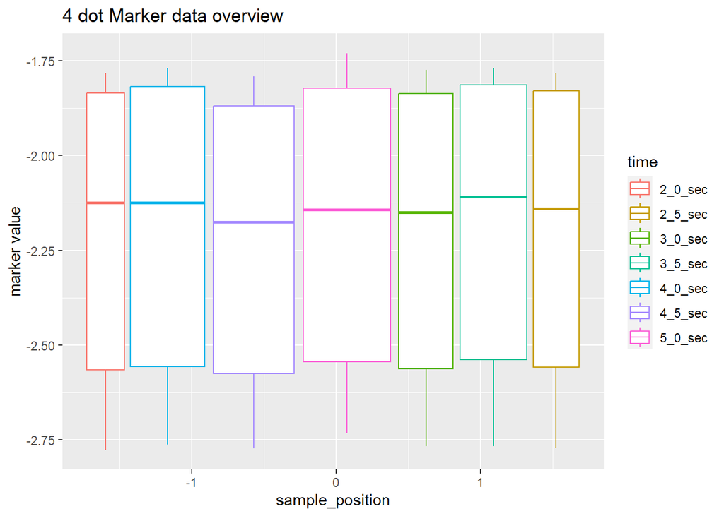

#### Distribution

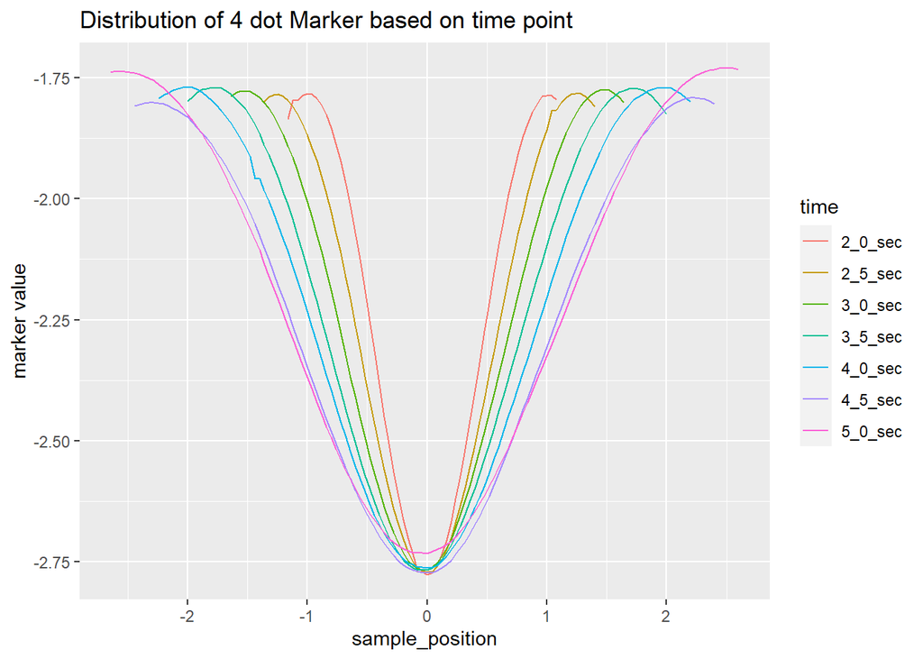

In every time point marker values follows the polynomial distribution for more clarity plot separately.

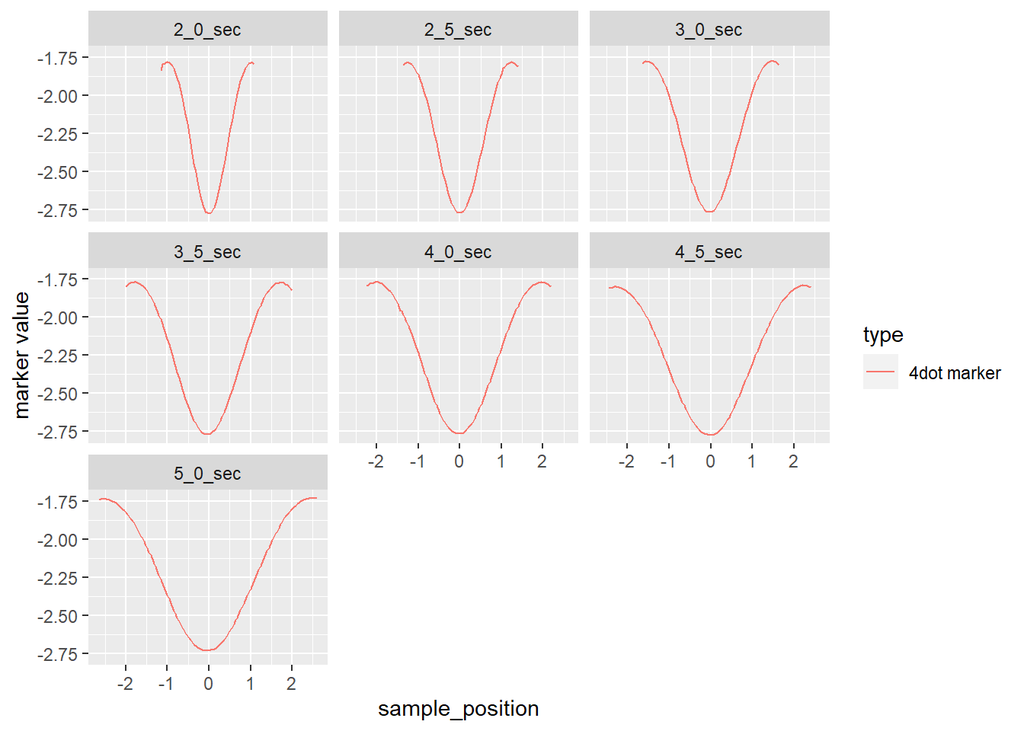

### 6 dot marker

#### Data overview

[figure not shown]

#### Distribution

[figure not shown]

In every time point marker values follows the polynomial distribution for more clarity plot separately.

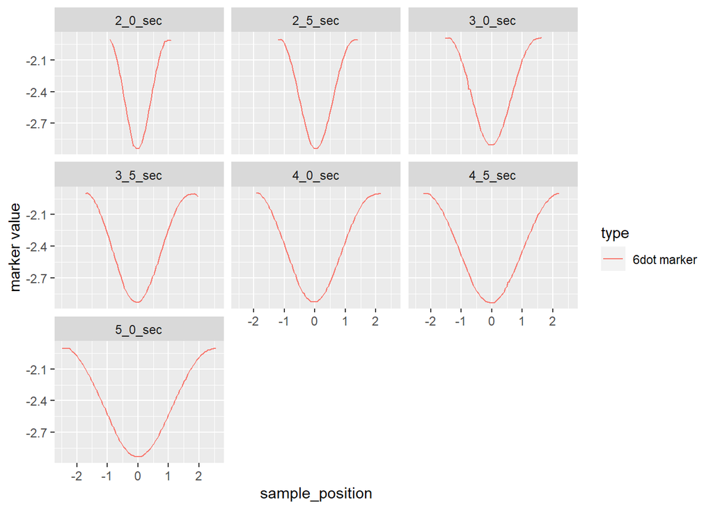

#### Combine both

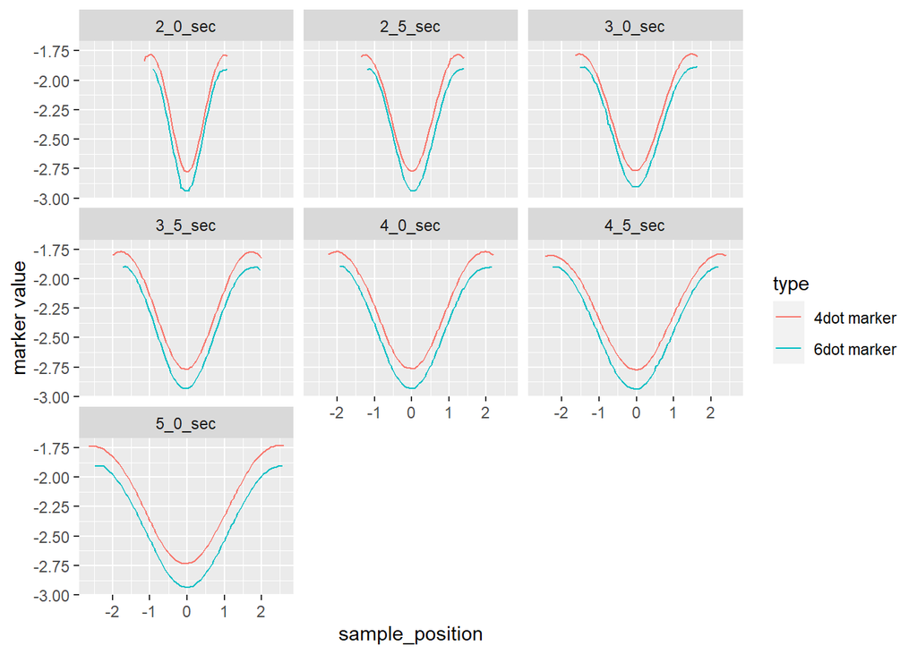

#### Polynomial regression

```
##           type    time Intercept          x1       x2          x3         x4
## 1  4dot marker 5_0_sec -2.184880  0.05900164 3.876829 -0.03941455 -1.4484076
## 2  6dot marker 5_0_sec -2.387461  0.11188979 3.910991 -0.14520170 -1.3112430
## 3  4dot marker 4_5_sec -2.226602  0.04022607 3.615703 -0.01668870 -1.4296187
## 4  6dot marker 4_5_sec -2.398046  0.01807223 3.705130 -0.05892226 -1.1781245
## 5  4dot marker 4_0_sec -2.193590  0.02325385 3.508741 -0.02617265 -1.5302803
## 6  6dot marker 4_0_sec -2.377490  0.53230103 3.467061 -0.57365564 -1.1647468
## 7  4dot marker 3_5_sec -2.186757  0.09574483 3.301620 -0.16430351 -1.5279981
## 8  6dot marker 3_5_sec -2.364582  0.57668223 3.266212 -0.66753073 -1.1769657
## 9  4dot marker 3_0_sec -2.204741  0.08292418 3.022723 -0.10296377 -1.2610902
## 10 6dot marker 3_0_sec -2.339524  0.26709914 3.038094 -0.32987735 -1.1656387
## 11 4dot marker 2_5_sec -2.205484  0.09581464 2.759544 -0.11052380 -1.1915925
## 12 6dot marker 2_5_sec -2.368777  0.25461059 2.819043 -0.30254273 -1.0434712
## 13 4dot marker 2_0_sec -2.200181 -0.21901626 2.459611  0.28431852 -1.1056947
## 14 6dot marker 2_0_sec -2.384575  0.48458803 2.414688 -0.50280917 -0.8098569
##              NA
## 1   0.025968462
## 2   0.056753162
## 3   0.015149071
## 4   0.049001955
## 5  -0.002537639
## 6   0.175439822
## 7   0.059628648
## 8   0.222070616
## 9   0.036755633
## 10  0.157755749
## 11  0.026885017
## 12  0.126903255
## 13 -0.077234144
## 14  0.156530302
```

#### Graphical representation

[figure not shown]